# ECON266_Problem Set 2_Seungho Choi

Seungho Choi

2025-09-21

```r
library(tidyverse)
```

```r
# load the proper package
library (data.table)
# load the dataset -- this command is new
data = data.frame(read.csv(file="bertrand2004.csv", header = TRUE, sep = ","))
```

### 1. To get the exercise started, let’s map an economic question into data. Define the following variables:

| Symbol | Name in R | Description |
| --- | --- | --- |
| Ci | call | Whether an applicant got a call back |
| Wi | race | Whether the applicant is white or not |
| Mi | sex | Whether the applicant is a male |
| Expi | yearsexp | Years of experience of the applicant |
| Educi | education | Education level of the applicant |

#### (a) What is the interpretation of C_bar in this situation?

Hint: this is a 0/1 variable like a coin flip, so what is the mean of a Bernoulli?

C_bar in general is a sample mean of the variable C. In this specific case, with the given information, as the variable C indicates whether an applicant got a call back or not, it is a dichotomous variable. In other words, it is a variable that has only two possible values, just like the Bernoulli.

##### Therefore, since C_bar is a sample mean of the dichotomous variable, the interpretation of it will be the proportion of all applicants who received a callback.

#### (b) What about M_bar? Hint: the same as the previous hint.

M_bar is also a dichotomous variable, but in this case the possible outcomes will be either male or not.

##### Therefore, the interpretation of M_bar will be the proportion of all applicants who were male.

### 2.Calculate the mean years of experience and education by sex.

```r
data %>%
  group_by(sex) %>%
  summarise(
    across(
      c(yearsexp, education),
      c(mean = ~ mean(.x)))
  )
```

```
## # A tibble: 2 × 3
##   sex   yearsexp_mean education_mean
##   <chr>         <dbl>          <dbl>
## 1 f              7.96           3.61
## 2 m              7.58           3.79
```

- mean years of experience: 7.964218 (female) / 7.579042 (male)
- mean years of education: 3.611784 (female) / 3.791328 (male)

### 3. Calculate the standard errors and do a t-test (by hand or using the test commands) for whether years of experience or education are diﬀerent by sex.

#### - Manual Calculation

```r
mydata <- data %>%
  group_by(sex) %>%
  reframe(
    count = n(),
    across(
      c(yearsexp, education),
      list(
        mean = ~mean(.x),
        sd = ~sd(.x),
        se = ~sd(.x) / sqrt(n())
        )
      )
    )
select(mydata, yearsexp_se, education_se)
```

```
## # A tibble: 2 × 2
##   yearsexp_se education_se
##         <dbl>        <dbl>
## 1      0.0820       0.0101
## 2      0.157        0.0193
```

```r
# Manual t-test for years of experience
manaual_t_tstat_yearsexp <-
  (mydata$yearsexp_mean[1] - mydata$yearsexp_mean[2]) /
  sqrt(
    mydata$yearsexp_se[1]^2 + mydata$yearsexp_se[2]^2
  )
manaual_t_tstat_yearsexp
```

```
## [1] 2.178841
```

```r
# Manual t-test for years of education
manaual_t_tstat_education <-
  (mydata$education_mean[1] - mydata$education_mean[2]) /
  sqrt(
    mydata$education_se[1]^2 + mydata$education_se[2]^2
  )
manaual_t_tstat_education
```

```
## [1] -8.257774
```

#### - Using test commands

```r
t.test(
  filter(data, sex == "f")["yearsexp"],
  filter(data, sex == "m")["yearsexp"]
)
```

```
##
##  Welch Two Sample t-test
##
## data:  filter(data, sex == "f")["yearsexp"] and filter(data, sex == "m")["yearsexp"]
## t = 2.1788, df = 1757.3, p-value = 0.02948
## alternative hypothesis: true difference in means is not equal to 0
## 95 percent confidence interval:
##  0.03845428 0.73189772
## sample estimates:
## mean of x mean of y
##  7.964218  7.579042
```

```r
t.test(
  filter(data, sex == "f")["education"],
  filter(data, sex == "m")["education"]
)
```

```
##
##  Welch Two Sample t-test
##
## data:  filter(data, sex == "f")["education"] and filter(data, sex == "m")["education"]
## t = -8.2578, df = 1752.5, p-value = 2.888e-16
## alternative hypothesis: true difference in means is not equal to 0
## 95 percent confidence interval:
##  -0.2221881 -0.1369004
## sample estimates:
## mean of x mean of y
##  3.611784  3.791328
```

##### Both manual calculation and using the test command are showing the same t-test results.

- Manual: 2.178841 (Experience), -8.257774 (Education)
- Command: 2.1788 (Experience), -8.2578 (Education)

##### In case of years of experience, the results of the t-test shows a statistically significant difference between male and female applicants.

- p-value: 0.02948 < 0.05 -> reject the null hypothesis
- confidence interval: [0.03845428, 0.73189772] -> entire interval is positive -> does not contain zero

##### In case of years of education, the results of the t-test shows a highly statistically significant difference between male and female applicants.

- p-value: 2.888e-16 < 0.05 -> reject the null hypothesis
- confidence interval: [-0.2221881, -0.1369004] -> entire interval is negative -> does not contain zero

### 4. Now, using the same commands (or any other commands you prefer), calculate the diﬀerence in call back rates by sex.

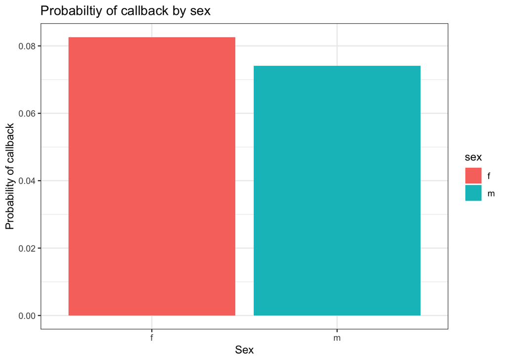

```r
data %>%
  group_by(sex) %>%
  summarise(mean = mean(call)) %>%
  ggplot(aes(x=sex, y=mean, fill=sex)) +
  geom_col() +
  labs(x="Sex", y="Probability of callback", title = "Probabiltiy of callback by sex") +
  theme_bw()
```

```r
data %>%
  group_by(sex) %>%
  summarise(
    across(
      c(call),
      c(mean = ~ mean(.x)))
  )
```

```
## # A tibble: 2 × 2
##   sex   call_mean
##   <chr>     <dbl>
## 1 f        0.0826
## 2 m        0.0741
```

- As shown from both the graph and the command, the probability of callback is higher in case of female (0.08259349) than male (0.07407407).

### 5. Perform a t-test to see if these diﬀerences are statistically significant. You may do this by hand, with the t.test command, or with any other command.

```r
t.test(
  filter(data, sex == "f")["call"],
  filter(data, sex == "m")["call"]
)
```

```
##
##  Welch Two Sample t-test
##
## data:  filter(data, sex == "f")["call"] and filter(data, sex == "m")["call"]
## t = 0.9385, df = 1892, p-value = 0.3481
## alternative hypothesis: true difference in means is not equal to 0
## 95 percent confidence interval:
##  -0.009283908  0.026322738
## sample estimates:
##  mean of x  mean of y
## 0.08259349 0.07407407
```

##### The results of the t-test indicate that there is no statistically significant difference in the callback rates between male and female applicants.

- p-value: 0.3481 > 0.05 -> Fail to reject the null hypothesis
- confidence interval: [-0.009283908, 0.026322738] -> includes zero